# DATA 607: Data Science in Context - K Nearest Neighbors

Eric Lehmphul

10/26/2021

# What is KNN

- Supervised learning algorithm used in both **classification** and **regression** problems
  - In classification problems, new data points will be classified in a particular class
  - In regression problems, new data points will be labeled based on the average value of k determined nearest neighbors
- Uses the proximity between points to determine label data points
  - Euclidean
  - Manhattan
  - Minkowski
- Normalization of the data is important to eliminate bias
  - Min-Max Normalization
  - Z-Score Normalization
- Considered a lazy learner algorithm

# Why use KNN

- It is simple and intuitive.
- Does not require any specific assumptions be made concerning the data and can be applied to any data distribution.

# Limitations of KNN

- Accuracy of model depends on the quality of the data.
- If using a large number of predictors and or number of records, calculating the distances between points will be computationally expensive.

# Euclidean Distance

- Most popular distance measure used in KNN

$$Distance = \sqrt{(x_1 - u_1)^2 + (x_2 - u_2)^2 + ...+(x_p - u_p)^2}$$

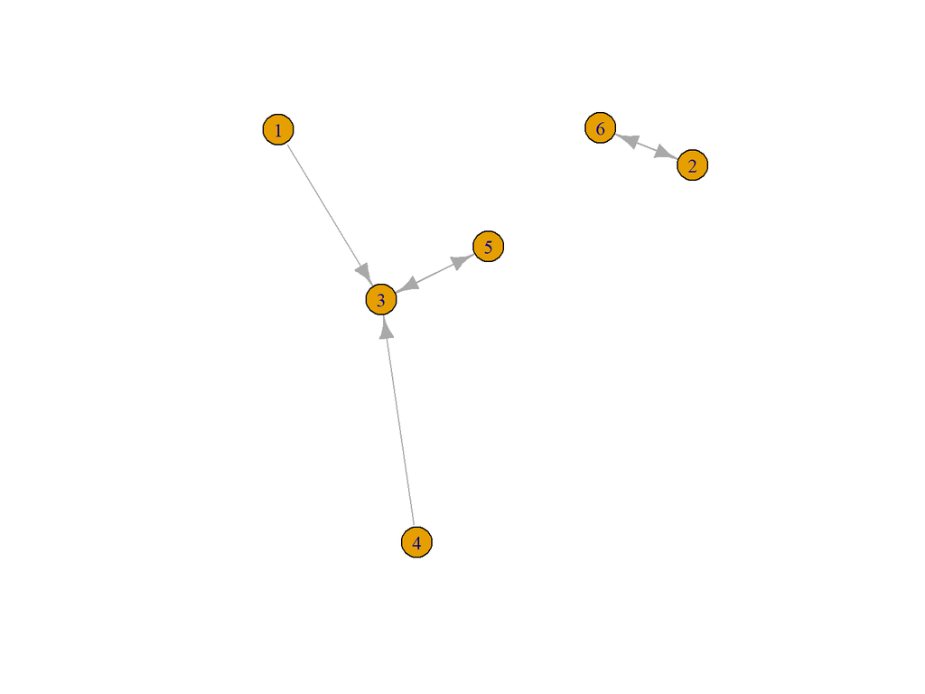

# Choosing k

- **k** is the number of nearby neighbors to be used to classify the new record
  - If k is too small it is sensitive to noise
  - If k is too large it may include may include majority points from other classes
- The square root of the training dataset is usually a good value for k, but not always the optimal k.

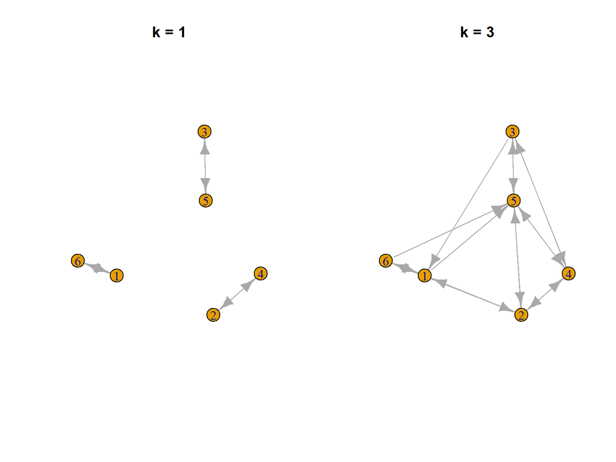

# Demo: Classifying Fruit

- Load Libraries
- Read Dataset
- Normalize Data
- Create Training and Testing Dataframes
- Create Model
- Model Results

# Load Libraries

```r
library(class) # for knn model
library(caret) # for confusion matrix
```

```r
library(ggplot2) # for graphs
library(gghighlight) # also for graphs
```

# Dataset

- The data contains descriptive attributes related to a fruit’s diameter, weight, and RGB color intensity.
- Target Variable:
  - Fruit (Grapefruit or Orange)
- Predictor Variables:
  - Diameter of Fruit
  - Weight of Fruit
  - Red color intensity
  - Green color intensity
  - Blue Color Intensity
- The dataset was acquired from Kaggle.com (https://www.kaggle.com/joshmcadams/oranges-vs-grapefruit)

```r
fruit.data <- read.csv("https://raw.githubusercontent.com/SaneSky109/DATA607/main/DataScienceInContext/Data/citrus.csv")

fruit.data$name <- factor(fruit.data$name)

head(fruit.data)
```

```
##     name diameter weight red green blue
## 1 orange     2.96  86.76 172    85    2
## 2 orange     3.91  88.05 166    78    3
## 3 orange     4.42  95.17 156    81    2
## 4 orange     4.47  95.60 163    81    4
## 5 orange     4.48  95.76 161    72    9
## 6 orange     4.59  95.86 142   100    2
```

# Normalize Data

- Since distance is the main measurement in knn, normalization is extremely important to eliminate bias.
- I scaled my data using Min-Max normalization.
  - $\frac{value-min}{max-min}$

```r
normalize <- function(x) {
  return((x - min(x)) / (max(x) - min(x)))
}
```

```r
norm.fruit <- as.data.frame(lapply(fruit.data[,-1], normalize))

norm.fruit$name <- fruit.data$name

head(norm.fruit)
```

```
##     diameter      weight       red     green       blue   name
## 1 0.00000000 0.000000000 0.7402597 0.6352941 0.00000000 orange
## 2 0.07042254 0.007381974 0.6623377 0.5529412 0.01851852 orange
## 3 0.10822832 0.048125894 0.5324675 0.5882353 0.00000000 orange
## 4 0.11193477 0.050586552 0.6233766 0.5882353 0.03703704 orange
## 5 0.11267606 0.051502146 0.5974026 0.4823529 0.12962963 orange
## 6 0.12083024 0.052074392 0.3506494 0.8117647 0.00000000 orange
```

# Create Training and Testing Data Frames

```r
set.seed(105)

data.sample <- sample(1:nrow(norm.fruit), size = nrow(norm.fruit)*0.7, replace = FALSE) # random sample of 70% of data

train.fruit <- norm.fruit[data.sample,]
test.fruit <- norm.fruit[-data.sample,]
```

# Create Model

- The **train** argument takes the training dataset (not including target variable)
- The **test** argument takes the testing dataset (not including target variable)
- The **cl** argument takes the vector of true classifications of the training dataset
- The **k** argument takes number of nearest neighbors considered

```r
model <- knn(train = train.fruit[,1:5], test = test.fruit[,1:5], cl = train.fruit[,6], k = sqrt(nrow(train.fruit)))
```

# Results

```r
actual <- test.fruit[,6]

results <- table(model, actual)
results
```

```
##             actual
## model        grapefruit orange
##   grapefruit       1412    111
##   orange            127   1350
```

```r
confusionMatrix(results)
```

```
## Confusion Matrix and Statistics
##
##             actual
## model        grapefruit orange
##   grapefruit       1412    111
##   orange            127   1350
##
##                Accuracy : 0.9207
##                  95% CI : (0.9104, 0.9301)
##     No Information Rate : 0.513
##     P-Value [Acc > NIR] : <2e-16
##
##                   Kappa : 0.8413
##
##  Mcnemar's Test P-Value : 0.3309
##
##             Sensitivity : 0.9175
##             Specificity : 0.9240
##          Pos Pred Value : 0.9271
##          Neg Pred Value : 0.9140
##              Prevalence : 0.5130
##          Detection Rate : 0.4707
##    Detection Prevalence : 0.5077
##       Balanced Accuracy : 0.9208
##
##        'Positive' Class : grapefruit
##
```

# Find Model with optimal k in terms of Accuracy

```r
k.optm <- 1

for (i in 1:sqrt(nrow(train.fruit))) {
  model <- knn(train = train.fruit[,1:5], test = test.fruit[,1:5], cl = train.fruit[,6], k = i)
  k.optm[i] <- 100*sum(test.fruit[,6]==model)/nrow(test.fruit)
  k <- i
  cat(k,'=', k.optm[i],'\n')
}
```

```
## 1 = 88.86667
## 2 = 89.46667
## 3 = 91.33333
## 4 = 90.7
## 5 = 91.3
## 6 = 91.1
## 7 = 91.5
## 8 = 91.56667
## 9 = 91.7
## 10 = 91.83333
## 11 = 91.73333
## 12 = 91.7
## 13 = 91.83333
## 14 = 91.8
## 15 = 91.83333
```

[output cut: 68 more lines]

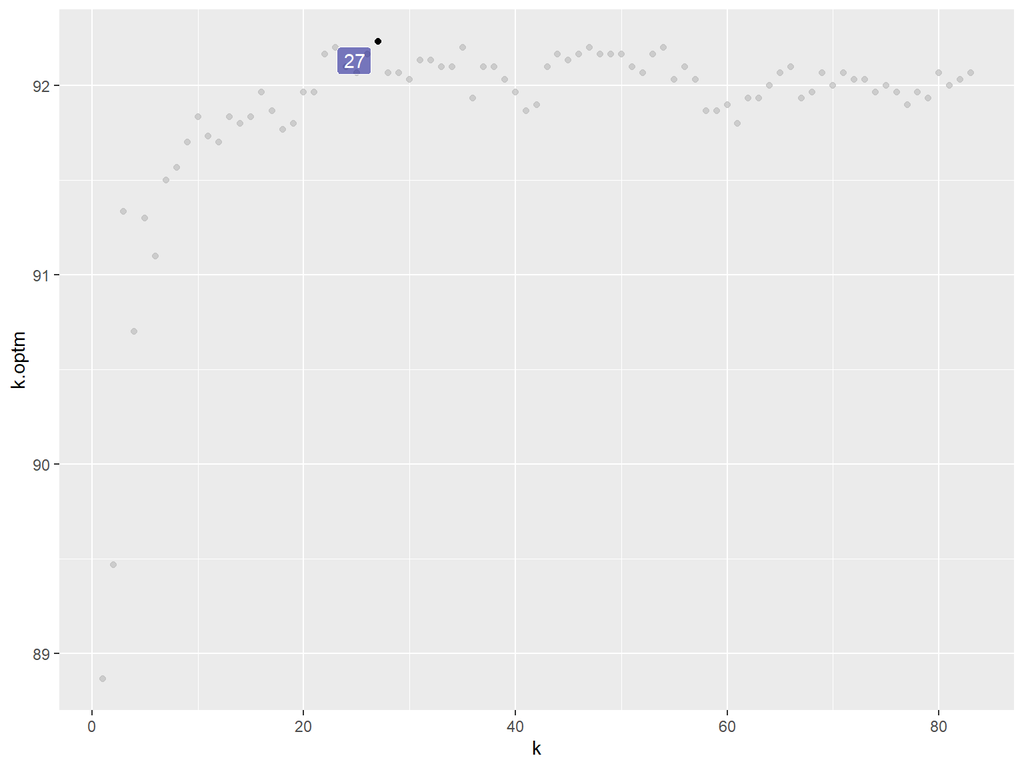

```r
accuracy<-as.data.frame(cbind(k = c(1:83),k.optm))
ggplot(accuracy, aes(x=k,y=k.optm)) +
  geom_point() +
  gghighlight(k.optm == max(k.optm)) +
  geom_label(aes(label = k),
              hjust = 1.2, vjust = 1.2, fill = "dark blue", colour = "white", alpha= 0.5)
```